# Australian RSPCA

```r
library(rpart)
library(rpart.plot)
library(here)
library(forcats)
library(janitor)
library(tidyverse)
```

The Data:

```r
townsville_complaints <- read_csv(here(
  "clean_data/townsville_complaints_clean.csv")
  )
townsville_complaints_tot_per_suburb <- read_csv(here(
  "clean_data/townsville_complaints_tot_per_suburb.csv")
  )
national_outcomes <- read_csv(here(
  "clean_data/national_outcomes_clean.csv")
  )
brisbane_complaints <- read_csv(here(
  "clean_data/brisbane_complaints_clean.csv")
  ) %>%
  mutate(suburb = str_to_title(suburb)
         )
brisbane_complaints_tot_per_suburb <- read_csv(here(
  "clean_data/brisbane_complaints_tot_per_suburb.csv")
  ) %>%
  mutate(suburb = str_to_title(suburb)
         )
townsville_complaints
```

| animal_type | complaint_type | date_received | suburb |
| --- | --- | --- | --- |
| dog | Aggressive Animal | June 2020 | Alice River |
| dog | Noise | June 2020 | Alice River |
| dog | Noise | June 2020 | Alice River |
| dog | Private Impound | June 2020 | Alice River |
| dog | Wandering | June 2020 | Alice River |
| dog | Attack | June 2020 | Black River |
| dog | Enclosure | June 2020 | Black River |
| dog | Wandering | June 2020 | Black River |
| dog | Enclosure | June 2020 | Bluewater |
| dog | Enclosure | June 2020 | Bluewater |

[output cut: 990 more lines]

```r
townsville_complaints_tot_per_suburb
```

| animal_type | complaint_type | suburb | total |
| --- | --- | --- | --- |
| cat | Enclosure | Aitkenvale | 16 |
| cat | Enclosure | Alice River | 4 |
| cat | Enclosure | Annandale | 20 |
| cat | Enclosure | Arcadia | 1 |
| cat | Enclosure | Black River | 3 |
| cat | Enclosure | Bohle Plains | 12 |
| cat | Enclosure | Burdell | 22 |
| cat | Enclosure | Bushland Beach | 25 |
| cat | Enclosure | Castle Hill | 1 |
| cat | Enclosure | Cluden | 1 |

[output cut: 590 more lines]

```r
brisbane_complaints
```

| animal_type | category | suburb | date_range |
| --- | --- | --- | --- |
| Dog | Fencing Issues | Sunnybank | january march 2016 |
| Dog | Fencing Issues | Sunnybank Hills | january march 2016 |
| Dog | Defecating In Public | Sunnybank | january march 2016 |
| Dog | Fencing Issues | Sunnybank | january march 2016 |
| Attack | Attack On An Animal | Calamvale | january march 2016 |
| Attack | Attack On A Person | Stretton | january march 2016 |
| Dog | Fox | Annerley | january march 2016 |
| Attack | Attack On An Animal | Forest Lake | january march 2016 |
| Dog | Fencing Issues | Hawthorne | january march 2016 |
| Dog | Defecating In Public | Hawthorne | january march 2016 |

[output cut: 990 more lines]

```r
brisbane_complaints_tot_per_suburb
```

| animal_type | category | suburb | total |
| --- | --- | --- | --- |
| Attack | Attack On A Person | Acacia Ridge | 39 |
| Attack | Attack On A Person | Albion | 1 |
| Attack | Attack On A Person | Alderley | 13 |
| Attack | Attack On A Person | Algester | 13 |
| Attack | Attack On A Person | Annerley | 11 |
| Attack | Attack On A Person | Anstead | 7 |
| Attack | Attack On A Person | Archerfield | 2 |
| Attack | Attack On A Person | Ascot | 7 |
| Attack | Attack On A Person | Ashgrove | 27 |
| Attack | Attack On A Person | Aspley | 34 |

[output cut: 990 more lines]

```r
national_outcomes
```

| year | animal_type | outcome | state | tot_outcomes |
| --- | --- | --- | --- | --- |
| 1999 | Dogs | Reclaimed | Australian Capital Territory | 610 |
| 1999 | Dogs | Reclaimed | New South Wales | 3140 |
| 1999 | Dogs | Reclaimed | Northern Territory | 205 |
| 1999 | Dogs | Reclaimed | Queensland | 1392 |
| 1999 | Dogs | Reclaimed | South Australia | 2329 |
| 1999 | Dogs | Reclaimed | Tasmania | 516 |
| 1999 | Dogs | Reclaimed | Victoria | 7130 |
| 1999 | Dogs | Reclaimed | Western Australia | 1 |
| 1999 | Dogs | Rehomed | Australian Capital Territory | 1245 |
| 1999 | Dogs | Rehomed | New South Wales | 7525 |

[output cut: 990 more lines]

## Complains type plots for Townsville and Brisbane

```r
townsville_complaints_tot_plot <- townsville_complaints %>%
  ggplot() +
  geom_bar(aes(y = fct_infreq(complaint_type),
                                   fill = animal_type)) +
  labs(x = "Complaint Type",
       y = "Totals",
       title = "Townsville Complaint Type Totals") +
  scale_fill_manual("Animal Type", values = c("cat" = "#74c066",
                                              "dog" = "#0193cf")
                    ) +
  theme_bw() +
  theme(text=element_text(size = 16, family = "Arial"),
        axis.text.x = element_text(angle = 45, hjust = 1),
        legend.position = "none") +
  facet_wrap(~ animal_type)


townsville_complaints_tot_plot
```

[output not shown]

[output not shown]

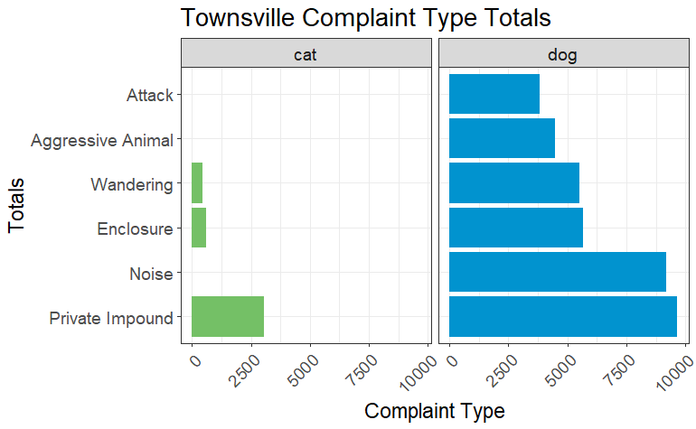

```r
ggsave("townsville_complaints_tot_plot.png")
```

In Townsville, dogs receive the more complaints. Calls regarding Cats are more concentrated on the welfare of the animal rather than proper annoyance like in dogs

```r
exclude <- c("Dog")

brisbane_complaints_tot_plot <- brisbane_complaints %>%
  mutate(animal_type = str_to_lower(animal_type)) %>%
  filter(animal_type %in% "cat" | animal_type %in% "dog") %>%
  filter(!category %in% exclude) %>%
  ggplot() +
  geom_bar(aes(y = fct_infreq(category), fill = animal_type)) +
  labs(x = "Complaint Type",
       y = "Totals",
       title = "Brisbane Complaint Type Totals") +
  scale_fill_manual("Animal Type", values = c("cat" = "#74c066",
                                              "dog" = "#0193cf")
                    ) +
  theme_bw() +
  theme(text=element_text(size = 16, family = "Arial"),
        axis.text.x = element_text(angle = 45, hjust = 1),
        legend.position = "none") +
  facet_wrap(~ animal_type)


brisbane_complaints_tot_plot
```

[output not shown]

[output cut: 13 more lines]

[output not shown]

[output not shown]

[output cut: 13 more lines]

[output not shown]

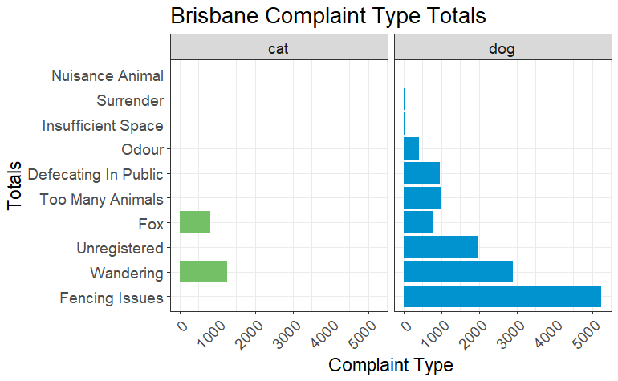

```r
ggsave("brisbane_complaints_tot_plot.png")
```

```r
brisbane_complaints %>%
  group_by(animal_type, category) %>%
  summarise(n = n())
```

| animal_type | category | n |
| --- | --- | --- |
| Attack | Attack On A Person | 2221 |
| Attack | Attack On An Animal | 3039 |
| Attack | Dangerous | 56 |
| Attack | Fencing Issues | 3 |
| Attack | Fox | 1042 |
| Attack | Menacing | 912 |
| Attack | Not An Attack | 1265 |
| Attack | Rabbit | 1 |
| Cat | Fox | 810 |
| Cat | Odour | 1 |

[output cut: 31 more lines]

In Brisbane again, dogs are again the focus of complains. We can notice some difference from Townsville, there is more variety of complains and looks like in Brisbane dogs have something for fences. Also, it seems to be an issue with foxes. Let’s look at this further.

## Brisbane vs Fox

```r
include <- "Fox"

brisbane_complaints_fox_plot <- brisbane_complaints %>%
  mutate(animal_type = str_to_lower(animal_type)) %>%
 # filter(!animal_type %in% "cat" | animal_type %in% "dog") %>%
  filter(category %in% include) %>%
  ggplot() +
  geom_bar(position = "dodge", aes(x = category, fill = animal_type)) +
  labs(x = "Complaint Type",
       y = "Totals",
       title = "Brisbane Fox Troubles") +
  scale_fill_manual("Grievances", values = c("cat trapping" = "#73182c",
                                             "other animal" = "#d6a115",
                                             "attack" = "#244321",
                                             "cat " = "#74c066",
                                             "dog" = "#0193cf")
                    ) +
  theme_bw() +
  theme(text=element_text(size = 16, family = "Arial"))

brisbane_complaints_fox_plot
```

[output not shown]

[output not shown]

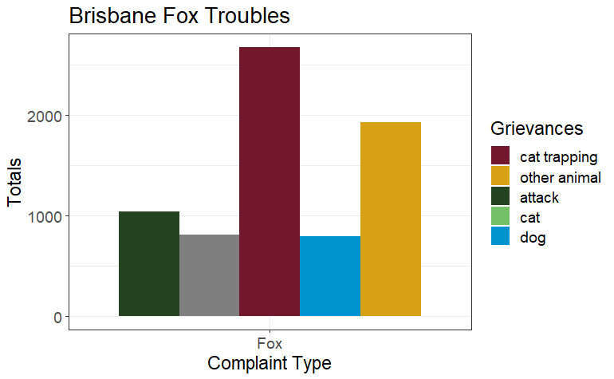

```r
ggsave("brisbane_complaints_fox_.png")
```

A fair amount of complaints are regarding foxes attacking dogs and cats and in particular trapping the latter. - Advise business to do campaign on keeping pets inside at home as long as it necessary.

```r
brisbane_complaints_fox_per_suburbs <- brisbane_complaints_tot_per_suburb %>%
  mutate(animal_type = str_to_lower(animal_type)) %>%
  #filter(!animal_type %in% "cat" | animal_type %in% "dog") %>%
  filter(category %in% include) %>%
  filter(total > 30) %>%
  ggplot() +
  geom_col(aes(y = suburb, x = total, fill = animal_type)) +
  labs(y = "Suburb",
       x = "Totals",
       title = "Brisbane Suburbs Fox Troubles*",
       caption = "* just considering Suburbs with more that 30 complaints") +
  scale_fill_manual("Grievances", values = c("cat trapping" = "#73182c",
                                              "attack" = "#244321",
                                              "other animal" = "#d6a115")
                    ) +
  scale_y_discrete(limits = rev) +
  theme_bw() +
  theme(text=element_text(size = 10, family = "Arial"),
        plot.caption = element_text(hjust = 1.4, face = "italic"))

brisbane_complaints_fox_per_suburbs
```

[output not shown]

[output not shown]

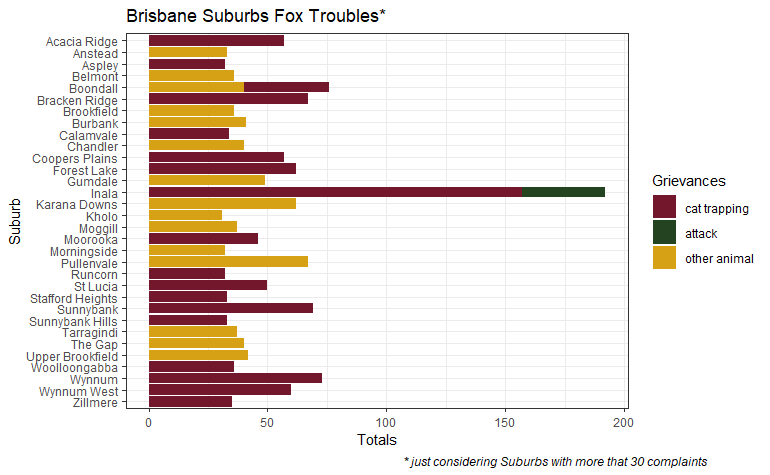

```r
ggsave("brisbane_complaints_fox_per_suburbs.png")
```

If we look at the fox problem by suburb, we notice that the cat trapping issue is particularly felt in Inala.

- insert map of Inala

```r
brisbane_complaints_by_suburbs <- brisbane_complaints_tot_per_suburb %>%
  mutate(animal_type = str_to_lower(animal_type)) %>%
  filter(animal_type %in% "cat" | animal_type %in% "dog") %>%
  filter(!category %in% exclude) %>%
  filter(total > 50) %>%
  drop_na() %>%
  ggplot() +
  geom_col(aes(y = suburb, x = total, fill = animal_type)) +
  labs(y = "Suburb",
       x = "Totals",
       title = "Brisbane Suburbs Pets Complaints*",
       caption = "* just considering Suburbs with more that 50 complaints") +
   scale_fill_manual("Animal Type", values = c("cat" = "#74c066",
                                              "dog" = "#0193cf")
                    ) +
  scale_y_discrete(limits = rev) +
  theme_bw() +
  theme(text=element_text(size = 10, family = "Arial"),
        axis.text.x = element_text(angle = 60, hjust = 1),
        plot.caption = element_text(hjust = 1.4, face = "italic"))

brisbane_complaints_by_suburbs
```

[output not shown]

[output not shown]

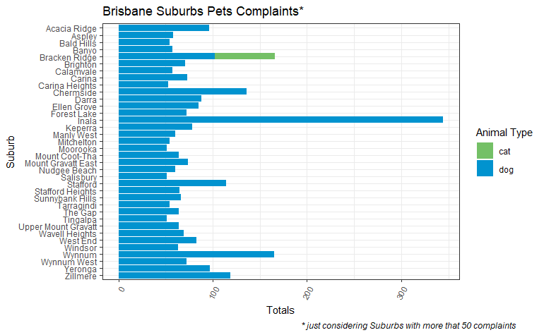

```r
ggsave("brisbane_complaints_by_suburbs.png")
```

- action in Bracken Ridge

```r
brisbane_subs_complaints_type_dogs <- brisbane_complaints_tot_per_suburb %>%
  mutate(category = str_to_lower(category)) %>%
  filter(animal_type == "Dog") %>%
  filter(!category %in% exclude) %>%
  filter(total > 50) %>%
  drop_na() %>%
  ggplot() +
  geom_col(aes(y = suburb, x = total, fill = category)) +
  labs(y = "Suburb",
       x = "Totals",
       title = "Brisbane Suburbs Pets Complaints Type - Dogs*",
       caption = "* just considering Suburbs with more that 50 complaints") +
  scale_fill_manual("Complaints Type", values = c("fencing issues" = "#74c066",
                                                  "unregistered" = "#244321",
                                                  "wandering" = "#d6a115")
                    ) +
  scale_y_discrete(limits = rev) +
  theme_bw() +
  theme(text=element_text(size = 10, family = "Arial"),
        plot.caption = element_text(hjust = 1.4, face = "italic"))

brisbane_subs_complaints_type_dogs
```

[output not shown]

[output not shown]

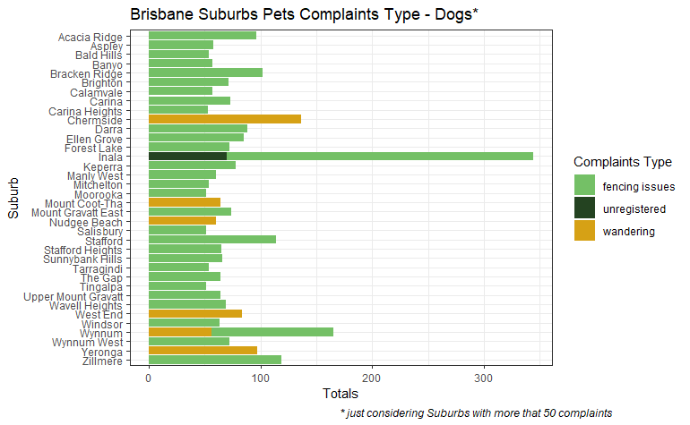

```r
ggsave("brisbane_subs_complaints_type_dogs.png")
```

```r
NA
```

Looking deeper to the type of complaints regarding dogs, most of them are for fencing issue, troubles between neighbors.

- prevent dogs damage fence?

```r
brisbane_subs_complaints_type_cats <- brisbane_complaints_tot_per_suburb %>%
  mutate(category = str_to_lower(category)) %>%
  filter(animal_type == "Cat") %>%
  filter(!category %in% exclude) %>%
  filter(total > 10) %>%
  drop_na() %>%
  ggplot() +
  geom_col(aes(y = suburb, x = total, fill = category)) +
  labs(y = "Suburb",
       x = "Totals",
       title = "Brisbane Suburbs Pets Complaints Type - Cats*",
       caption = "* just considering Suburbs with more that 10 complaints") +
  scale_fill_manual("Complaints Type", values = c("fox" = "#74c066",
                                                  "wandering" = "#0193cf")
                    ) +
  scale_y_discrete(limits = rev) +
  theme_bw() +
  theme(text=element_text(size = 10, family = "Arial"),
        plot.caption = element_text(hjust = 1.4, face = "italic"))

brisbane_subs_complaints_type_cats
```

[output not shown]

[output not shown]

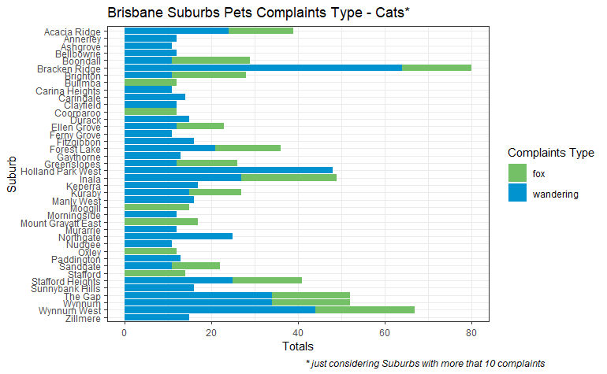

```r
ggsave("brisbane_subs_complaints_type_cats.png")
```

If we look at cats, again the two main problems are wandering and foxes.

```r
brisbane_complaints %>%
  filter(animal_type == "Dog" | animal_type == "Cat") %>%
  group_by(animal_type, suburb) %>%
  summarise(n = n()) %>%
  arrange(desc(n))
```

| animal_type | suburb | n |
| --- | --- | --- |
| Dog | Inala | 453 |
| Dog | NA | 292 |
| Dog | Wynnum | 248 |
| Dog | Chermside | 233 |
| Dog | Bracken Ridge | 224 |
| Dog | Zillmere | 224 |
| Dog | Forest Lake | 200 |
| Dog | Keperra | 196 |
| Dog | Stafford | 193 |
| Dog | Yeronga | 190 |

[output cut: 346 more lines]

```r
townsville_complaints_by_suburbs <- townsville_complaints_tot_per_suburb %>%
  filter(total > 30) %>%
  ggplot() +
  geom_col(aes(y = suburb, x = total, fill = animal_type)) +
  labs(y = "Suburb",
       x = "Totals",
       title = "Townsville Suburbs Complaints Totals",
       caption = "* just considering Suburbs with more that 30 complaints") +
  scale_fill_manual("Complaints Type", values = c("cat" = "#74c066",
                                                  "dog" = "#0193cf")
                    ) +
  scale_y_discrete(limits = rev) +
  theme_bw() +
  theme(text=element_text(size = 10, family = "Arial"),
        plot.caption = element_text(hjust = 1.4, face = "italic"))

townsville_complaints_by_suburbs
```

[output not shown]

[output not shown]

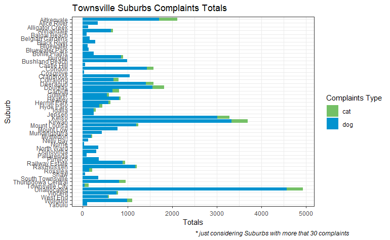

```r
ggsave("townsville_complaints_by_suburbs.png")
```

Going to Townsville suburbs, and dogs are at it again. Most complains are directed to dogs

```r
townsville_complaints_type_cats <- townsville_complaints_tot_per_suburb %>%
  mutate(complaint_type = str_to_lower(complaint_type)) %>%
  filter(animal_type == "cat") %>%
  filter(total > 10) %>%
  filter(!suburb == "Unallocated") %>%
  ggplot() +
  geom_col(aes(y = suburb, x = total, fill = complaint_type)) +
  labs(y = "Suburb",
       x = "Totals",
       title = "Townsville Suburbs Complaints Cats",
       caption = "* just considering Suburbs with more that 10 complaints") +
  scale_fill_manual("Complaints Type", values = c("enclosure" = "#74c066",
                                                  "private impound" = "#0193cf",
                                                  "wandering" = "#244321")
                    ) +
  scale_y_discrete(limits = rev) +
  theme_bw() +
  theme(text=element_text(size = 10, family = "Arial"),
        axis.text.x = element_text(angle = 60, hjust = 1),
        plot.caption = element_text(hjust = 1.4, face = "italic"))

townsville_complaints_type_cats
```

[output not shown]

[output not shown]

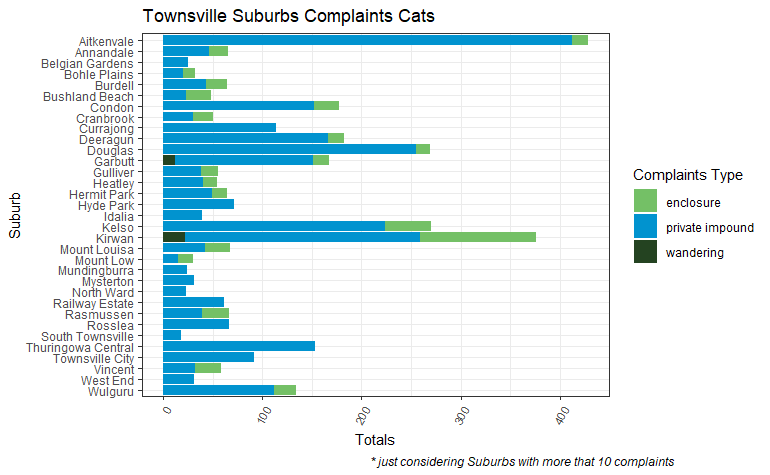

```r
ggsave("townsville_complaints_type_cats.png")
```

Again for cats we notice that most if not all the complaints calls are regarding the welfare of the animal, private impound means when a person than it’s not part of RSCA contacts them because he took in an animal because they are concerned regarding its state. Enclosure is when an animal is trapped and wandering is moslty directed to strays or lost pets.

```r
townsville_complaints_type_dogs <- townsville_complaints_tot_per_suburb %>%
  mutate(complaint_type = str_to_lower(complaint_type)) %>%
  filter(!animal_type == "cat") %>%
  filter(total > 50) %>%
  filter(!suburb == "Unallocated") %>%
  ggplot() +
  geom_col(aes(y = suburb, x = total, fill = complaint_type)) +
  labs(y = "Suburb",
       x = "Totals",
       title = "Townsville Suburbs Complaints Totals",
       caption = "* just considering Suburbs with more that 50 complaints") +
  scale_fill_manual("Complaints Type", values = c("enclosure" = "#74c066",
                                                  "private impound" = "#0193cf",
                                                  "wandering" = "#244321",
                                                  "attack" = "#d6a115",
                                                  "noise" = "#73182c",
                                                  "aggressive animal" = "#ff0000")
                    ) +
  scale_y_discrete(limits = rev) +
  theme_bw() +
  theme(text=element_text(size = 10, 0.1, family = "Arial"),
        plot.caption = element_text(hjust = 1.4, face = "italic"))

townsville_complaints_type_dogs
```

[output not shown]

[output not shown]

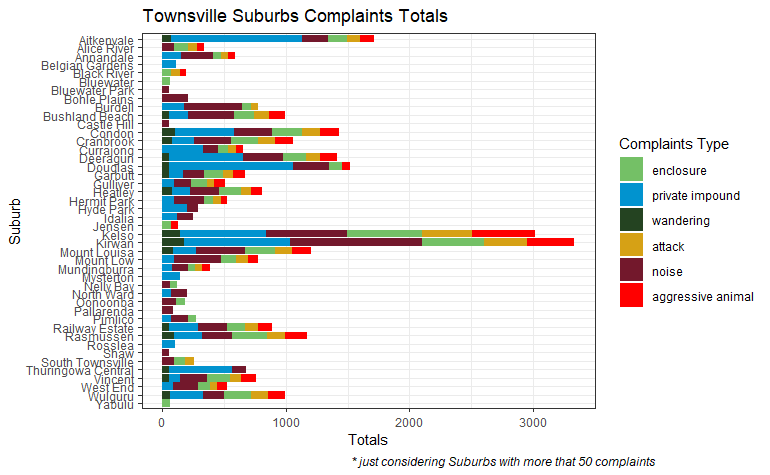

```r
ggsave("townsville_complaints_type_dogs.png")
```

RSPCA should probably led a further enquire on pets welfare in this suburbs and concentrate a campaign on how to be a good dog owner.

```r
townsville_dog_bars <- townsville_complaints %>%
  filter(animal_type == "dog") %>%
  group_by(complaint_type) %>%
  summarise(total = n()) %>%
  arrange(desc(total))

townsville_dog_bars
```

| complaint_type | total |
| --- | --- |
| Private Impound | 9646 |
| Noise | 9205 |
| Enclosure | 5672 |
| Wandering | 5501 |
| Aggressive Animal | 4459 |
| Attack | 3836 |

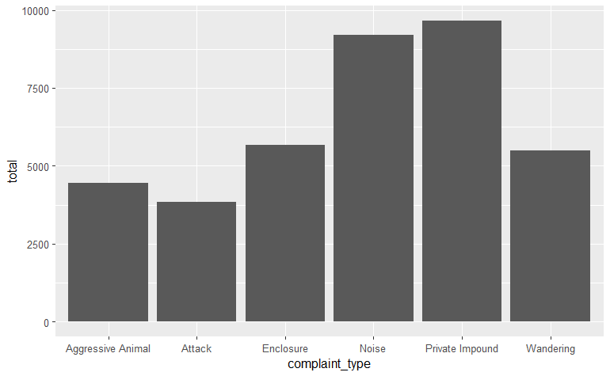

```r
ggplot(townsville_dog_bars) +
  geom_col(aes(x = complaint_type, y = total))
```

```r
NA
NA
NA
```

```r
townsville_cat_bars <- townsville_complaints %>%
  filter(animal_type == "cat") %>%
  group_by(complaint_type) %>%
  summarise(total = n()) %>%
  arrange(desc(total))

townsville_cat_bars
```

| complaint_type | total |
| --- | --- |
| Private Impound | 3046 |
| Enclosure | 610 |
| Wandering | 438 |

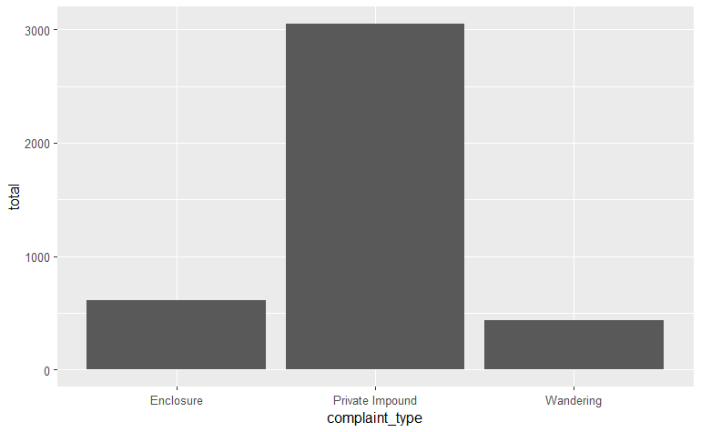

```r
ggplot(townsville_cat_bars) +
  geom_col(aes(x = complaint_type, y = total))
```

```r
brisbane_dog_bars <- brisbane_complaints %>%
  filter(animal_type == "Dog") %>%
  group_by(category) %>%
  summarise(total = n()) %>%
  arrange(desc(total))

brisbane_dog_bars
```

| category | total |
| --- | --- |
| Fencing Issues | 5244 |
| Wandering | 2908 |
| Unregistered | 1977 |
| Too Many Animals | 983 |
| Defecating In Public | 955 |
| Fox | 794 |
| Odour | 403 |
| Insufficient Space | 50 |
| Surrender | 15 |
| Dog | 4 |

[output cut: 1 more lines]

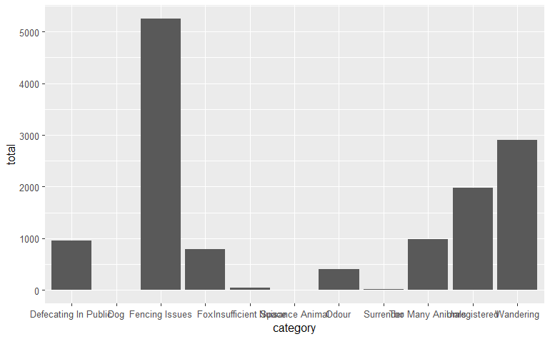

```r
ggplot(brisbane_dog_bars) +
  geom_col(aes(x = category, y = total))
```

```r
NA
NA
NA
```

```r
brisbane_cat_bars <- brisbane_complaints %>%
  filter(animal_type == "Cat") %>%
  group_by(category) %>%
  summarise(total = n()) %>%
  arrange(desc(total))

brisbane_cat_bars
```

| category | total |
| --- | --- |
| Wandering | 1258 |
| Fox | 810 |
| Odour | 1 |
| Unregistered | 1 |

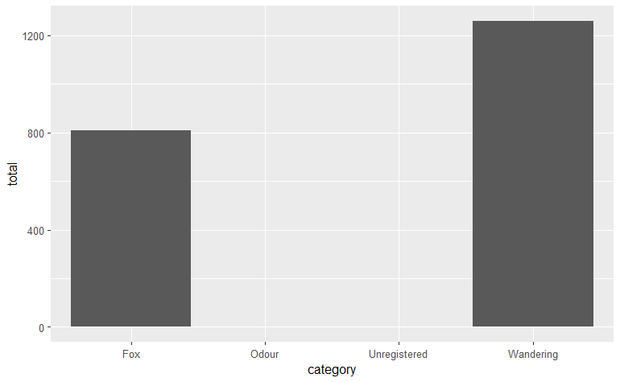

```r
ggplot(brisbane_cat_bars) +
  geom_col(aes(x = category, y = total))
```

[output not shown]

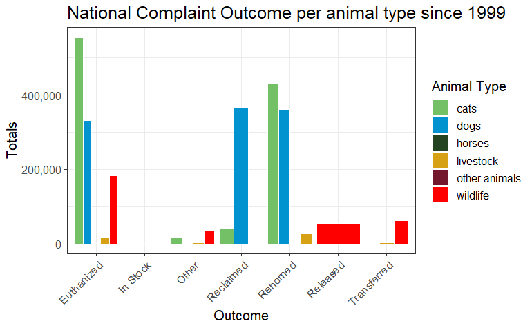

```r
national_outcomes_animail_type <-  national_outcomes %>%
  filter(!outcome == "Currently In Care") %>% # Currently in Care refers to animal in RSPCA custody waiting for an outcome, as the outcome is not defined yet for these cases I have excluded it from the plot
  mutate(animal_type = str_to_lower(animal_type)) %>%
  group_by(animal_type, outcome) %>%
  summarise(tot = sum(tot_outcomes)) %>%
  drop_na() %>%
  ggplot() +
  geom_col(position = "dodge", colour = "white", aes(x = outcome,
                                                     y = tot,
                                                     fill = animal_type)
           )+
  labs(x = "Outcome",
       y = "Totals",
       title = "National Complaint Outcome per animal type since 1999") +
  scale_fill_manual("Animal Type", values = c("cats" = "#74c066",
                                                  "dogs" = "#0193cf",
                                                  "horses" = "#244321",
                                                  "livestock" = "#d6a115",
                                                  "other animals" = "#73182c",
                                                  "wildlife" = "#ff0000")
                    ) +
  scale_y_continuous(labels = scales::comma) +
  theme_bw() +
  theme(text=element_text(size = 14, family = "Arial"),
        axis.text.x = element_text(angle = 45, hjust = 1))
national_outcomes_animail_type
```

```r
national_outcomes_pets <-  national_outcomes %>%
  filter(!outcome == "Currently In Care") %>%
  filter(!outcome == "Other") %>%
  filter(animal_type == "Cats" | animal_type == "Dogs") %>%
  mutate(animal_type = str_to_lower(animal_type)) %>%
  group_by(animal_type, outcome) %>%
  summarise(tot = sum(tot_outcomes)) %>%
  drop_na() %>%
  ggplot() +
  geom_col(position = "dodge", colour = "white", aes(y = fct_infreq(outcome),
                                                     x = tot,
                                                     fill = animal_type)
           )+
  labs(y = "Outcome",
       x = "Totals",
       title = "National Complaint Outcome per animal type since 1999") +
  scale_fill_manual("Animal Type", values = c("cats" = "#74c066",
                                                  "dogs" = "#0193cf")
                    ) +
  scale_x_continuous(labels = scales::comma) +
  theme_bw() +
  theme(text=element_text(size = 14, family = "Arial"),
        axis.text.x = element_text(angle = 45, hjust = 1),
        legend.position = "none") +
  facet_wrap(~animal_type)
national_outcomes_pets
```

[output not shown]

[output not shown]

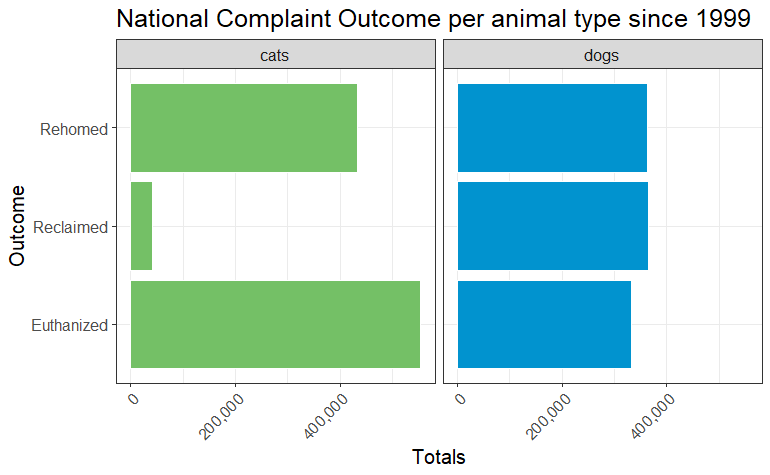

```r
ggsave("national_outcomes_pets.png")
```

The outcome for complaint when the animal is taken in custody by RSPCA from 1999. The most common outcome for cats is to be euthanised, and they are not reclaimed as often a dogs and I am not sure how many how the rehoming are successful, I can imagine that a cat that gets returned to RSPCA or ends up again in the street is not a rare scenario, that would explain the difference in numbers for euthanised and reclaimed with dogs.

The number of cats and dogs in the data set is almost equivalent so I tend to belive the above hypothesis.

Cats 1117506  
Dogs 1149320

```r
euthanisation_trend_cats_dogs <- national_outcomes %>%
  filter(animal_type == "Cats" | animal_type == "Dogs") %>%
  filter(outcome == "Euthanized") %>%
  mutate(animal_type = str_to_lower(animal_type)) %>%
  group_by(year, animal_type, outcome) %>%
  summarise(tot_outcomes = sum(tot_outcomes)) %>%
  ungroup() %>%
  ggplot() +
  geom_line(size = 2,aes(x = year,
                         y = tot_outcomes,
                         group = animal_type,
                         colour = animal_type)
            ) +
  labs(x = "Year",
       y = "Euthanisations",
       title = "Cats & Dogs Euthanisation trend since 1999") +
  scale_colour_manual("Animal Type", values = c("cats" = "#74c066",
                                              "dogs" = "#0193cf")
                    ) +
  theme_bw() +
  theme(text=element_text(size = 14, family = "Arial"))
euthanisation_trend_cats_dogs
```

[output not shown]

[output not shown]

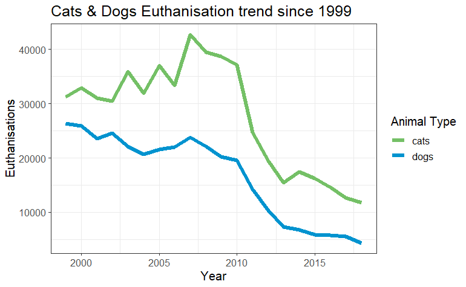

```r
ggsave("euthanisation_trend_cats_dogs.png")
```

The good news is that the trend is changing, since the 2010s euthanisations have dropped drastically.

```r
rehoming_trendcats_dogs <- national_outcomes %>%
  filter(animal_type == "Cats" | animal_type == "Dogs") %>%
  filter(outcome == "Rehomed") %>%
  mutate(animal_type = str_to_lower(animal_type)) %>%
  group_by(year, animal_type, outcome) %>%
  summarise(tot_outcomes = sum(tot_outcomes)) %>%
  ungroup() %>%
  ggplot() +
  geom_line(size = 2,aes(x = year,
                         y = tot_outcomes,
                         group = animal_type,
                         colour = animal_type)
            ) +
  labs(x = "Year",
       y = "Rehomed",
       title = "Cats & Dogs Rehomed trend since 1999") +
  scale_colour_manual("Animal Type", values = c("cats" = "#74c066",
                                              "dogs" = "#0193cf")
                    ) +
  theme_bw() +
  theme(text=element_text(size = 14, family = "Arial"))
rehoming_trendcats_dogs
```

[output not shown]

[output not shown]

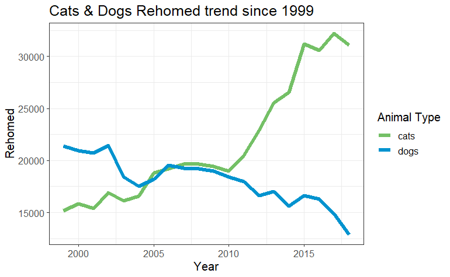

```r
ggsave("rehoming_trendcats_dogs.png")
```

Rehoming numbers for cats have increase drastically since the 2010s, but again I have doubts on how many of these were succesful.

```r
reclaimed_trendcats_dogs <- national_outcomes %>%
  filter(animal_type == "Cats" | animal_type == "Dogs") %>%
  filter(outcome == "Reclaimed") %>%
  mutate(animal_type = str_to_lower(animal_type)) %>%
  group_by(year, animal_type, outcome) %>%
  summarise(tot_outcomes = sum(tot_outcomes)) %>%
  ungroup() %>%
  ggplot() +
  geom_line(size = 2,aes(x = year,
                         y = tot_outcomes,
                         group = animal_type,
                         colour = animal_type)
            ) +
  labs(x = "Year",
       y = "Recaimed",
       title = "Cats & Dogs Reclaimed trend since 1999") +
  scale_colour_manual("Animal Type", values = c("cats" = "#74c066",
                                              "dogs" = "#0193cf")
                    ) +
  theme_bw() +
  theme(text=element_text(size = 14, family = "Arial"))
reclaimed_trendcats_dogs
```

[output not shown]

[output not shown]

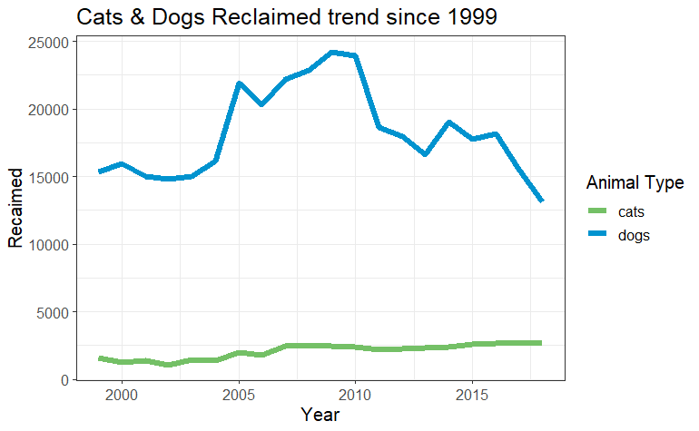

```r
ggsave("reclaimed_trendcats_dogs.png")
```

The reclaimed trends for cats hasn’t been that great and it’s stable during the years. For dog the trend is going down although this couldn’t been so gloom, with the diffusion of social media and in particular neighbourhood pages, when a dog go missing the voice is spread quickly and usualy they are found before RSPCA intervention.

```r
national_outcomes %>%
  filter(animal_type == "Cats" | animal_type == "Dogs") %>%
  group_by(animal_type) %>%
  drop_na() %>%
  summarise(tot_outcomes = sum(tot_outcomes))
```

| animal_type | tot_outcomes |
| --- | --- |
| Cats | 1117506 |
| Dogs | 1149320 |

```r
national_outcomes %>%
  filter(animal_type == "Dogs" | animal_type == "Cats") %>%
  filter(outcome == "Euthanized" |
         outcome == "Rehomed" |
         outcome == "Reclaimed") %>%
  group_by(animal_type, outcome) %>%
  drop_na() %>%
  summarise(tot = sum(tot_outcomes))
```

| animal_type | outcome | tot |
| --- | --- | --- |
| Cats | Euthanized | 553956 |
| Cats | Reclaimed | 41409 |
| Cats | Rehomed | 432448 |
| Dogs | Euthanized | 332547 |
| Dogs | Reclaimed | 364579 |
| Dogs | Rehomed | 362093 |

Plain numbers above

## Decision Tree

Preparing the data set for the decision tree

```r
tree_national_outcomes <- rowid_to_column(national_outcomes, "id") %>%
  drop_na()

decision_tree_try <- data.frame(lapply(tree_national_outcomes,
                                       rep,
                                       tree_national_outcomes$tot_outcomes))
```

```r
clean_national_test <- decision_tree_try %>%
  #filter(year == "2018") %>%
  filter(animal_type == "Dogs" | animal_type == "Cats") %>%
  filter(outcome == "Euthanized" |
         outcome == "Rehomed" ) %>%
   mutate(animal_type = as.factor(animal_type),
         state = as.numeric(factor(state)),
         outcome = as.numeric(factor(outcome))
         ) %>%
  mutate(state = factor(state, levels = c(1,2,3,4,5,6,7,8),
                        labels = c("Australian Capital Territory",
                                   "New South Wales",
                                   "Northern Territory",
                                   "Queensland",
                                   "South Australia",
                                   "Tasmania",
                                   "Victoria",
                                   "Western Australia")),
         outcome = factor(outcome, levels = c(1,2),
                              labels = c("Euthanized", "Rehomed"))
         ) %>%
  select(-id, -tot_outcomes)

clean_national_test
```

| year | animal_type | outcome | state |
| --- | --- | --- | --- |
| 1999 | Dogs | Rehomed | Australian Capital Territory |
| 1999 | Dogs | Rehomed | Australian Capital Territory |
| 1999 | Dogs | Rehomed | Australian Capital Territory |
| 1999 | Dogs | Rehomed | Australian Capital Territory |
| 1999 | Dogs | Rehomed | Australian Capital Territory |
| 1999 | Dogs | Rehomed | Australian Capital Territory |
| 1999 | Dogs | Rehomed | Australian Capital Territory |
| 1999 | Dogs | Rehomed | Australian Capital Territory |
| 1999 | Dogs | Rehomed | Australian Capital Territory |
| 1999 | Dogs | Rehomed | Australian Capital Territory |

[output cut: 990 more lines]

```r
n_data <- nrow(clean_national_test)

test_index <- sample(1:n_data, size = n_data*0.2)

outcomes_test  <- slice(clean_national_test, test_index)

outcomes_train <- slice(clean_national_test, -test_index)

outcomes_test %>%
  tabyl(outcome)
```

```
    outcome      n   percent
 Euthanized 177367 0.5275514
    Rehomed 158841 0.4724486
```

```r
outcomes_train %>%
  tabyl(outcome)
```

```
    outcome      n  percent
 Euthanized 709136 0.527303
    Rehomed 635700 0.472697
```

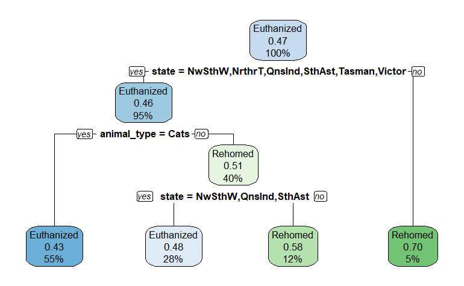

```r
outcome_fit_state <- rpart(
  formula = outcome ~ animal_type + state,
  data = outcomes_train,
  method = 'class'
)

rpart.plot(outcome_fit_state ,
           yesno = 2,
           fallen.leaves = TRUE,
           faclen = 6,
           digits = 2)
```

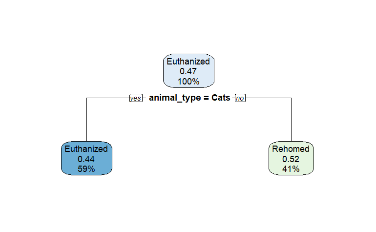

```r
outcome_fit_animal <- rpart(
  formula = outcome ~ animal_type,
  data = outcomes_train,
  method = 'class'
)

rpart.plot(outcome_fit_animal,
           yesno = 2,
           fallen.leaves = TRUE,
           faclen = 6,
           digits = 2)
```

```r
outcome_fit_all <- rpart(
  formula = outcome ~ .,
  data = outcomes_train,
  method = 'class'
)

rpart.plot(outcome_fit_all,
           yesno = 2,
           fallen.leaves = TRUE,
           faclen = 6,
           digits = 2)
```

[output not shown]